# Project: Machine Learning project on Enron Data

The goal of this project is to analyze the characteristics of employees who worked at Enron during the crisis period (between year 2000 and year 2001)to predict if they are a person of interest ("POI").

Various resources (documentaries, news articles, etc.) were used to label people in the data set as POIs if they were previously indicted (that is, there is a 100% chance they were guilty).

There are a total of 146 people in the enron dataset I am working on. Out of 146 people, 18 are labelled as POI and 128 are Non-POI. There are a total of 20 email & financial features.

Machine learning used on this project may be of assistance if we take the predictions from the Enron data model and apply them to other companies facing similar circumstances. It would be an assumption though that other companies are similar to Enron, in their business functioning.

The features included in the dataset can be divided in three main categories, Payment Features, Stock Features and Email Features.

Bellow I have given a brief definition for each one.

## Payment Features

salary - Reflects items such as base salary, executive cash allowances, and benefits payments.

deferral_payments - Reflects distributions from a deferred compensation arrangement due to termination of employment or due to in-service withdrawals as per plan provisions.

loan_advances - Reflects total amount of loan advances, excluding repayments, provided by the Debtor in return for a promise of repayment. In certain instances, the terms of the promissory notes allow for the option to repay with stock of the company.

bonus - Reflects annual cash incentives paid based upon company performance. Also may include other retention payments.

long_term_incentive - Reflects long-term incentive cash payments from various long-term incentive programs designed to tie executive compensation to long-term success over a multi-year period, generally 3 to 5 years.

deferred_income - Reflects an arrangement in which a portion of an employee's income is paid out at a later date after which the income was earned. Examples of deferred compensation include pensions, retirement plans, and employee stock options.

expenses - Reflects reimbursements of business expenses. May include fees paid for consulting services.

Other - Reflects items such as payments for severence, consulting services, relocation costs, tax advances and allowances for employees on international assignment. May also include payments provided with respect to employment agreements, as well as imputed income amounts for such things as use of corporate aircraft.

director_fees - Reflects cash payments and/or value of stock grants made in lieu of cash payments to non-employee directors.

total_payments Sum of the above values

## Stock Features

Stock Value Definitions of Category Groupings

restricted_stock_deferred - Reflects value of restricted stock voluntarily deferred prior to release under a deferred compensation arrangement.

exercised_stock_options - Reflects amounts from exercised stock options which equal the market value in excess of the grant (strike) price of the option at the time of receiving them.

restricted_stock - Reflects stock of a company that is not fully transferable (from the stock-issuing company to the person receiving the stock award) until certain conditions have been met. Upon satisfaction of those conditions, the stock is no longer restricted, and becomes transferable to the person holding the award. It is the gross fair market value of shares and accrued dividends is stock of a company as of today.

total_stock_value - Sum of the above values

## Email features

to_messages - Total number of emails received (person's inbox)

email_address - Email address of the person

from_poi_to_this_person - Number of emails received by this person from a POI

from_messages - Total number of emails sent by this person

from_this_person_to_poi - Number of emails sent by this person to a POI.

shared_receipt_with_poi - Number of emails received by this person, where he was in CC, along with the POI.

poi - This is the most important feature in our dataset. This has a boolean value of True or False. It is True if the person is marked as 'Person of interest', and False if not.

```python
import os
import sys
import pickle

import numpy as np
import math
import pandas as pd
import matplotlib.pyplot as plt
import seaborn as sns

import sklearn
from sklearn.feature_selection import SelectKBest, f_classif
from sklearn.naive_bayes import GaussianNB
from sklearn.svm import SVC
from sklearn.tree import DecisionTreeClassifier
from sklearn.tree import tree
from sklearn.ensemble import AdaBoostClassifier
from sklearn.linear_model import LogisticRegression
from sklearn.ensemble import RandomForestClassifier
from sklearn.cross_validation import train_test_split

from sklearn.model_selection import GridSearchCV
from sklearn.preprocessing import StandardScaler
from sklearn.pipeline import Pipeline
from sklearn.decomposition import PCA
from sklearn.pipeline import FeatureUnion

from sklearn.metrics import average_precision_score
from sklearn.metrics import make_scorer
from sklearn.metrics import f1_score, accuracy_score
from sklearn.metrics import precision_score
from sklearn.metrics import recall_score
import warnings; warnings.simplefilter('ignore')

cwd = os.getcwd()
print(cwd)
```

```
/Users/poonam/Documents/DAND/DAND-ML-Project5
```

```python
# Load the dictionary containing the dataset
with open("final_project_dataset.pkl", "rb") as data_file:
    data_dict = pickle.load(data_file)

enron_data_df = pd.DataFrame.from_dict(data_dict, orient = 'index')
enron_data_df.shape

print(enron_data_df.head())
print(enron_data_df.describe())

print ("There are a total of {} people in the dataset."
       .format(len(enron_data_df.index)))
print ("Out of which {} are POI and {} Non-POI."
       .format(enron_data_df['poi'].value_counts()[True],
               enron_data_df['poi'].value_counts()[False]))
print ("Total number of email & financial features are {}, this includes POI identifier"
       .format(len(enron_data_df.columns)))
```

```
                    salary to_messages deferral_payments total_payments  \
ALLEN PHILLIP K     201955        2902           2869717        4484442
BADUM JAMES P          NaN         NaN            178980         182466
BANNANTINE JAMES M     477         566               NaN         916197
BAXTER JOHN C       267102         NaN           1295738        5634343
BAY FRANKLIN R      239671         NaN            260455         827696

                   loan_advances    bonus               email_address  \
ALLEN PHILLIP K              NaN  4175000     phillip.allen@enron.com
BADUM JAMES P                NaN      NaN                         NaN
BANNANTINE JAMES M           NaN      NaN  james.bannantine@enron.com
BAXTER JOHN C                NaN  1200000                         NaN
BAY FRANKLIN R               NaN   400000         frank.bay@enron.com

                   restricted_stock_deferred deferred_income  \
ALLEN PHILLIP K                      -126027        -3081055
BADUM JAMES P                            NaN             NaN
BANNANTINE JAMES M                   -560222           -5104
BAXTER JOHN C                            NaN        -1386055
BAY FRANKLIN R                        -82782         -201641

                   total_stock_value      ...      from_poi_to_this_person  \
ALLEN PHILLIP K              1729541      ...                           47
BADUM JAMES P                 257817      ...                          NaN
BANNANTINE JAMES M           5243487      ...                           39
BAXTER JOHN C               10623258      ...                          NaN
BAY FRANKLIN R                 63014      ...                          NaN

                   exercised_stock_options from_messages    other  \
ALLEN PHILLIP K                    1729541          2195      152
BADUM JAMES P                       257817           NaN      NaN
BANNANTINE JAMES M                 4046157            29   864523
BAXTER JOHN C                      6680544           NaN  2660303
BAY FRANKLIN R                         NaN           NaN       69

                   from_this_person_to_poi    poi  long_term_incentive  \
ALLEN PHILLIP K                         65  False               304805
BADUM JAMES P                          NaN  False                  NaN
BANNANTINE JAMES M                       0  False                  NaN
BAXTER JOHN C                          NaN  False              1586055
```

[output cut: 35 more lines]

```
count     146                 146                     146              146
unique      2                  53                      84               98
top     False                 NaN                     NaN              NaN
freq      128                  80                      60               36

       director_fees
count            146
unique            18
top              NaN
freq             129

[4 rows x 21 columns]
There are a total of 146 people in the dataset.
Out of which 18 are POI and 128 Non-POI.
Total number of email & financial features are 21, this includes POI identifier
```

```python
enron_data_df = pd.DataFrame.from_dict(data_dict, orient = 'index')
enron_data_df.shape
```

```
(146, 21)
```

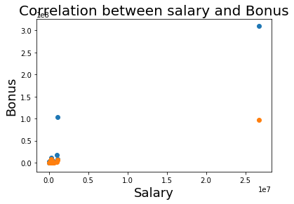

```python
# Check correlation between Salary and Bonus
# To see correlation between values draw scatter plots

chart = plt.scatter(x=enron_data_df.salary, y=enron_data_df.total_payments)
plt.title('Correlation between salary and total_payments', fontsize=20)
plt.xlabel('Salary', fontsize=18)
plt.ylabel('Total Payments', fontsize=18)

chart = plt.scatter(x=enron_data_df.salary, y=enron_data_df.bonus)
plt.title('Correlation between salary and Bonus', fontsize=20)
plt.xlabel('Salary', fontsize=18)
plt.ylabel('Bonus', fontsize=18)
plt.show()
```

```python
# Remove outlier TOTAL and THE TRAVEL AGENCY IN THE PARK from dict
data_dict.pop('TOTAL', None)
data_dict.pop('THE TRAVEL AGENCY IN THE PARK', None)
# Remove email_address column
data_dict.pop('email_address', None)

print (len(data_dict))

# Note- features_list without email_address
features_list = ['poi','salary', 'to_messages', 'deferral_payments', 'total_payments',
       'loan_advances', 'bonus','restricted_stock_deferred',
       'deferred_income', 'total_stock_value', 'expenses',
       'from_poi_to_this_person', 'exercised_stock_options', 'from_messages',
       'other', 'from_this_person_to_poi', 'long_term_incentive',
       'shared_receipt_with_poi', 'restricted_stock', 'director_fees']
```

```
144
```

```python
finance_cols = [ 'salary','deferral_payments', 'deferred_income','loan_advances', 'bonus','expenses',
                'long_term_incentive','director_fees', 'other', 'total_payments']
for record in data_dict.values():
    for col in finance_cols:
        if record[col] == 'NaN':
           record[col] = 0

stock_cols = ['restricted_stock_deferred', 'exercised_stock_options',
              'restricted_stock','total_stock_value']
for record in data_dict.values():
    for col in stock_cols:
        if record[col] == 'NaN':
           record[col] = 0

email_cols = [ 'to_messages', 'from_poi_to_this_person',
              'from_messages', 'from_this_person_to_poi','shared_receipt_with_poi']
# make all 0 except email_address
for record in data_dict.values():
    for col in email_cols:
        if record[col] == 'NaN':
           record[col] = 0
```

### Outlier Analysis

From the scatter chart we see that not all points are visible. There are one or more outliers in the dataset. On inspection I find that there is one row with name as 'TOTAL', and there is one with name as 'THE TRAVEL AGENCY IN THE PARK', these two are not person names, and have huge values. I remove these values and plot the scatter chart again.

```python
## recreate dataframe without Total
enron_data_df = pd.DataFrame.from_dict(data_dict,orient='index')
```

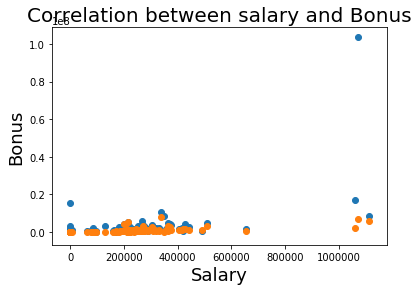

```python
# To see correlation between values draw scatter plots
chart = plt.scatter(x=enron_data_df.salary, y=enron_data_df.total_payments)
plt.title('Correlation between salary and total_payments', fontsize=20)
plt.xlabel('Salary', fontsize=18)
plt.ylabel('Total Payments', fontsize=18)


chart = plt.scatter(x=enron_data_df.salary, y=enron_data_df.bonus)
plt.title('Correlation between salary and Bonus', fontsize=20)
plt.xlabel('Salary', fontsize=18)
plt.ylabel('Bonus', fontsize=18)
plt.show()
```

The scaller chart looks better now after removing the TOTAL value row.

Also I removed the email_address column from the dataset. It is the only string value column in the dataset, all others integer type. If we convert the NaN in the email_address column to zero, it wouldn't be correct as it is string.

```python
# remove email address column
if 'email_address' in list(enron_data_df.columns.values):
    enron_data_df.drop('email_address', axis=1, inplace=True)

#enron_data_df.drop('email_address', axis=1, inplace=True)
print (enron_data_df.shape)
```

```
(144, 20)
```

### What features did you end up using in your POI identifier, and what selection process did you use to pick them? Did you have to do any scaling? Why or why not?

Enron dataset is weak in terms of the information provided. There are lots of NaN values for most of the features. Some features have more than 50% of their values missing, as we can see from the frequency of NaN from the table above.

I replaced all the NaN values with zero.

If I chose to drop all NaNs, that would reduce the size of what is already a small dataset. As the quality of a machine learning model is proportional to the amount of data fed into it, I am hesitant to remove any information that could possibly be of use. I felt this was the best way to handle the missing values.

Statistical tests can be used to select those features that have the strongest relationship with the output variable.

The scikit-learn library provides the SelectKBest class that can be used with a suite of different statistical tests to select a specific number of features.

I used SelectKBest as the 'automated feature selection' method. Below is the code that shows how the list of top features can be drawn. I have given k=10 here to get top 10 features. K can be given any value upto max number of features.

Following were the top 10 best features.

['poi','exercised_stock_options','total_stock_value','bonus','salary', 'deferred_income','long_term_incentive','restricted_stock', 'total_payments', 'shared_receipt_with_poi','loan_advances']

I created four new features mentioned below. However they were not used for the final evaluation. I used them to make classifiers but they did not enhance the model, so they were dropped.

bonus_by_total = enron_data_df['bonus']/ enron_data_df['total_payments']

salary_by_total = enron_data_df['salary']/ enron_data_df['total_payments']

to_poi_by_total_msg = enron_data_df['from_this_person_to_poi']/ enron_data_df['from_messages']

from_poi_by_total_msg = enron_data_df['from_poi_to_this_person']/ enron_data_df['to_messages']

```python
#from feature_format import featureFormat (if separate file- else def functions here)
#from feature_format import targetFeatureSplit

def featureFormat(dictionary, features, remove_NaN=True, remove_all_zeroes=True, remove_any_zeroes=False, sort_keys = False):
    return_list = []
    if isinstance(sort_keys, str):
        import pickle
        keys = pickle.load(open(sort_keys, "rb"))
    elif sort_keys:
        keys = sorted(dictionary.keys())
    else:
        keys = dictionary.keys()

    for key in keys:
        tmp_list = []
        for feature in features:
            try:
                dictionary[key][feature]
            except KeyError:
                print ("error: key ", feature, " not present")
                return
            value = dictionary[key][feature]
            if value=="NaN" and remove_NaN:
                value = 0
            tmp_list.append(float(value))

        append = True
        if features[0] == 'poi':
            test_list = tmp_list[1:]
        else:
            test_list = tmp_list
        if remove_all_zeroes:
            append = False
            for item in test_list:
                if item != 0 and item != "NaN":
                    append = True
                    break
        if remove_any_zeroes:
            if 0 in test_list or "NaN" in test_list:
                append = False
        if append:
            return_list.append( np.array(tmp_list) )
    return np.array(return_list)


def targetFeatureSplit( data ):
    target = []
    features = []
    for item in data:
        #print('target=' ,item[0])
        target.append( item[0] )
        features.append( item[1:] )
    return target, features


def get_k_best(data_dict, features_list, k):
    data = featureFormat(data_dict, features_list)
    labels, features = targetFeatureSplit(data)

    k_best = SelectKBest(k=k)
    k_best.fit(features, labels)
    scores = k_best.scores_
    unsorted_pairs = zip(features_list[1:], scores)
    sorted_pairs = list(reversed(sorted(unsorted_pairs, key=lambda x: x[1])))
    k_best_features = dict(sorted_pairs[:k])
    print("{0} best features: {1}\n".format(k, k_best_features.keys()))
    return k_best_features


k_best = get_k_best(data_dict, features_list, 10)
print (k_best)


print (k_best)
print (len(data_dict))


predictors_best10 = ['poi','exercised_stock_options', 'total_stock_value','bonus','salary','deferred_income','long_term_incentive',
 'restricted_stock', 'total_payments', 'shared_receipt_with_poi','loan_advances']

data = featureFormat(data_dict, predictors_best10)
labels, features = targetFeatureSplit(data)
```

```
10 best features: dict_keys(['exercised_stock_options', 'total_stock_value', 'bonus', 'salary', 'deferred_income', 'long_term_incentive', 'restricted_stock', 'total_payments', 'shared_receipt_with_poi', 'loan_advances'])

{'exercised_stock_options': 24.815079733218194, 'total_stock_value': 24.182898678566879, 'bonus': 20.792252047181535, 'salary': 18.289684043404513, 'deferred_income': 11.458476579280369, 'long_term_incentive': 9.9221860131898225, 'restricted_stock': 9.2128106219771002, 'total_payments': 8.7727777300…
{'exercised_stock_options': 24.815079733218194, 'total_stock_value': 24.182898678566879, 'bonus': 20.792252047181535, 'salary': 18.289684043404513, 'deferred_income': 11.458476579280369, 'long_term_incentive': 9.9221860131898225, 'restricted_stock': 9.2128106219771002, 'total_payments': 8.7727777300…
144
```

### Perform feature selection and Feature importances By SelectKBest

```
['salary' 'to_messages' 'deferral_payments' 'total_payments'
 'loan_advances' 'bonus' 'restricted_stock_deferred' 'deferred_income'
 'total_stock_value' 'expenses' 'from_poi_to_this_person'
 'exercised_stock_options' 'from_messages' 'other'
 'from_this_person_to_poi' 'long_term_incentive' 'shared_receipt_with_poi'
 'restricted_stock' 'director_fees']
```

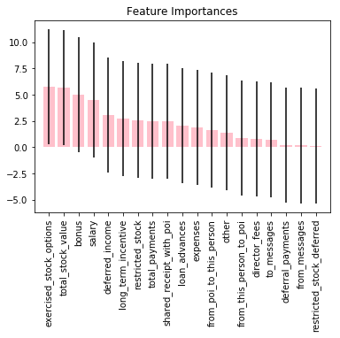

```python
predictors = enron_data_df.drop('poi', axis=1).columns.values
print (predictors)   # features_list without poi, also email_address removed earlier

selector = SelectKBest(f_classif, k=5)
selector.fit(enron_data_df[predictors], enron_data_df["poi"])

# Get the raw p-values for each feature, and transform from p-values into scores
scores = -np.log10(selector.pvalues_)

indices = np.argsort(scores)[::-1]

sorted_important_features=[]
for i in indices:
    sorted_important_features.append(predictors[i])

# Plot the scores.
plt.figure()
plt.title("Feature Importances")
plt.bar(range(np.size(predictors)), scores[indices],
       color="pink", yerr=np.std([indices]))
plt.xticks(range(np.size(predictors)), sorted_important_features, rotation='vertical')

plt.xlim([-1, np.size(predictors)])
plt.show()
```

```python
enron_data_df.shape
```

```
(144, 20)
```

### Add new features

```python
for key in data_dict:
    if (data_dict[key]['total_payments'] != 0):
        data_dict[key]["bonus_by_total"] = data_dict[key]['bonus']/data_dict[key]['total_payments']
        data_dict[key]['salary_by_total'] = data_dict[key]['salary']/data_dict[key]['total_payments']
    else:
       data_dict[key]["bonus_by_total"] = 1
       data_dict[key]['salary_by_total'] = 1

    if (data_dict[key]['from_messages'] != 0):
        data_dict[key]['to_poi_by_total_msg'] = data_dict[key]['from_this_person_to_poi']/data_dict[key]['from_messages']
    else:
        data_dict[key]['to_poi_by_total_msg'] = 1
    if (data_dict[key]['to_messages'] != 0):
        data_dict[key]['from_poi_by_total_msg'] = data_dict[key]['from_poi_to_this_person']/data_dict[key]['to_messages']
    else:
        data_dict[key]['from_poi_by_total_msg'] = 1
```

### Feature Selection

predictors_best15 = ['poi','salary', 'to_messages', 'deferral_payments', 'total_payments','loan_advances', 'bonus','restricted_stock_deferred', 'deferred_income', 'total_stock_value', 'expenses','from_poi_to_this_person', 'exercised_stock_options', 'from_messages', 'other', 'from_this_person_to_poi']

predictors_best12 = ['poi','exercised_stock_options', 'total_stock_value','bonus','salary','deferred_income','long_term_incentive', 'restricted_stock', 'total_payments', 'shared_receipt_with_poi','loan_advances','expenses', 'from_poi_to_this_person']

predictors_best10 = ['poi','exercised_stock_options', 'total_stock_value','bonus','salary','deferred_income','long_term_incentive', 'restricted_stock', 'total_payments', 'shared_receipt_with_poi','loan_advances']

predictors_best8 = ['poi','exercised_stock_options', 'total_stock_value','bonus','salary','deferred_income','long_term_incentive', 'restricted_stock', 'total_payments']

predictors_10with_new = ['poi','exercised_stock_options', 'total_stock_value','bonus','salary','deferred_income','long_term_incentive', 'bonus_by_total','salary_by_total', 'to_poi_by_total_msg', 'from_poi_by_total_msg']

predictors_8with_new = ['poi','exercised_stock_options', 'total_stock_value','bonus','salary', 'bonus_by_total','salary_by_total', 'to_poi_by_total_msg', 'from_poi_by_total_msg']

I also made features_list with new features that I created, but that also did not yield good precision and recall.

```python
predictors_best15 = ['poi','salary', 'to_messages', 'deferral_payments', 'total_payments','loan_advances', 'bonus',
                     'restricted_stock_deferred','deferred_income', 'total_stock_value', 'expenses',
                     'from_poi_to_this_person', 'exercised_stock_options', 'from_messages','other',
                     'from_this_person_to_poi']
```

```python
# Naive Beyes - GaussianNB
gnb_clf = GaussianNB()
scores = sklearn.cross_validation.cross_val_score(gnb_clf, features, labels)
print (scores)
print ('GaussianNB mean score:', scores.mean())


# Support Vector Machine (Classifier)
svc_clf = SVC()
scores = sklearn.cross_validation.cross_val_score(svc_clf, features, labels)
print (scores)
print ('SVC:', scores.mean())


# DecisionTree
dt_clf = DecisionTreeClassifier()
scores = sklearn.cross_validation.cross_val_score(dt_clf, features, labels)
print (scores)
print ('DecisionTree mean score:', scores.mean())


# AdaBoostClassifier
ab_clf = AdaBoostClassifier(n_estimators=100)
scores = sklearn.cross_validation.cross_val_score(ab_clf, features, labels)
print (scores)
print ('AdaBoostClassifier mean score:', scores.mean())


# Logistic Regression
lreg_clf = LogisticRegression()
scores = sklearn.cross_validation.cross_val_score(lreg_clf, features, labels)
print (scores)
print ('LogisticRegression mean score:', scores.mean())
```

```
[ 0.875       0.10416667  0.76595745]
GaussianNB mean score: 0.581708037825
[ 0.875       0.875       0.87234043]
SVC: 0.874113475177
[ 0.79166667  0.75        0.82978723]
DecisionTree mean score: 0.79048463357
[ 0.875       0.8125      0.87234043]
AdaBoostClassifier mean score: 0.853280141844
[ 0.75        0.83333333  0.82978723]
LogisticRegression mean score: 0.804373522459
```

As part of this project I had to predict the 'person of interest' correctly. This was a supervised machine learning project, where the lable was given. So the unsupervised algorithms were ruled out first.

The output had to be a boolean, with True False values, thus being dicrete and not continuos. So this was a classification problem.

As Naive Bayes and Support Vector Machine (Classifier) are used pretty exclusively for classification, I chose these two algorithms.

There are other algorithms like Decision Tree and KNearest Neighbors that can be used for both continuous and discrete.

Two more algorithms Adaboost and Random Forests in scikit learn are built using a base of a decision tree, so these also can be used for either continuous or discrete.

I ran the cross_val_score function on 5 algorithms, namely Naive Beyes, SVC, Decision Tree, AdaBoost and LogisticRegression. Following were the scores for each algorithm.

However for finalizing the classifier in the end I evaluated, SVC, DecisionTree, AdaBoost and RandomForest.

#### Extract the feature and label values from the data_dict using featureFormat and targetFeatureSplit functions.

Note that 'poi' is the first element in the predictors_best15 list. With poi there are 16 elements.

```python
data = featureFormat(data_dict, predictors_best15)
labels, features = targetFeatureSplit(data)
```

### Split into test and training data

```python
X_training_features, X_test_features, y_train_poi, y_test_poi = train_test_split(features, labels, test_size=0.33, random_state=42)

print ('Data has been split into training and testing set')
print ('Feature selection and parameter tuning begins to identify the best classifiers')
# precision is (true positives)/ (true positives + false positives)
# recall is (true positives)/ (true positives + false negatives)

k=15
min_precision = 0.3
min_recall = 0.3
```

```
Data has been split into training and testing set
Feature selection and parameter tuning begins to identify the best classifiers
```

### Make classifiers, Use GridSearchCV to automate the process of finding the optimal features and parameters on different algorithms

There are several parameters specific to an algorithm that can be tuned to get the best classifier. Firstly to know, the list of the parameters for each algorithm, I called the get_params() function as shown below.

#### Parameter List

estimated = estimator.get_params().keys()

print ('param_keys',estimated)

get_params() function was called invidually for all estimators SVC, DecisionTree, AdaBoost and RandomForest.

I created the pipeline function to execute the steps for parameter optimization. For each of the 4 algorithms I used SelectKBest as one of the step. SelectKBest returned the top 'k' best predictors. I utilised the output from get_params() to decide on the parameters I would use to create the param_grid for a particular classifier.

For final classifier I set k as 15.

Feature scaling though standardization/normalization can be an important preprocessing step for many machine learning algorithms. Standardization involves rescaling the features such that they have the properties of a standard normal distribution with a mean of zero and a standard deviation of one.

While many algorithms (such as SVM, K-nearest neighbors, and logistic regression) require features to be normalized, intuitively we can think of Principle Component Analysis (PCA) as being a prime example of when normalization is important. In PCA we are interested in the components that maximize the variance.

I used PCA for normalization. I used GridSearchCV funtion, with input as pipe and param_grid, to create the classifier. The precision recall was lower before PCA. After PCA it improved.

Below I have code for all the classifiers.

```python
print ('################### Try SVM ###################################')

svm_clf_1 = SVC(random_state=0)

pipe = Pipeline([
    ('scaler',StandardScaler()),
    ("kbest", SelectKBest(k=k)),
    ('classification', svm_clf_1)
])

# Check the parameters that can be set for DecisionTree Classifier, and create a param_grid
estimated = svm_clf_1.get_params().keys()
print ('param_keys########################',estimated)
#dict_keys(['C', 'cache_size', 'class_weight', 'coef0', 'decision_function_shape', 'degree', 'gamma', 'kernel', 'max_iter', 'probability', 'random_state', 'shrinking', 'tol', 'verbose'])

param_grid = ([{'classification__C': [100],
    'classification__gamma': [0.1],
    'classification__degree':[2],
    'classification__kernel': ['poly'],
    'classification__max_iter':[5]
}])
svm_clf_1 = GridSearchCV(pipe, param_grid, scoring='recall')
svm_clf_1.fit(X_training_features, y_train_poi).best_estimator_

clf_best = svm_clf_1.best_estimator_

y_poi_predicted = clf_best.predict(X_test_features)
f1_tree = f1_score(y_test_poi, y_poi_predicted)
precision_tree = precision_score(y_test_poi, y_poi_predicted)
recall_tree = recall_score(y_test_poi, y_poi_predicted)
print ('f1 score for DecisionTreeClassifier', f1_tree)
print ('precision for DecisionTreeClassifier', precision_tree)
print ('recall for DecisionTreeClassifier', recall_tree)

if (precision_tree >= min_precision) & (recall_tree >= min_recall):
    print ('DecisionTree is a good classifier with set parameters')
else:
    print ('Low precision and recall, DecisionTree is not a good classifier with set parameters')
```

```
################### Try SVM ###################################
param_keys######################## dict_keys(['C', 'cache_size', 'class_weight', 'coef0', 'decision_function_shape', 'degree', 'gamma', 'kernel', 'max_iter', 'probability', 'random_state', 'shrinking', 'tol', 'verbose'])
f1 score for DecisionTreeClassifier 0.0975609756098
precision for DecisionTreeClassifier 0.0571428571429
recall for DecisionTreeClassifier 0.333333333333
Low precision and recall, DecisionTree is not a good classifier with set parameters
```

```python
print ('################### Try DecisionTreeClassifier ###################################')
# DecisionTree - 1
tree_clf_1 = tree.DecisionTreeClassifier(random_state=0)

# Create a pipeline with feature selection and classification
pipe = Pipeline([
  ('feature_selection', SelectKBest(k=k)),
  ('classification', tree_clf_1)
])

# Check the parameters that can be set for DecisionTree Classifier, and create a param_grid
estimated = tree_clf_1.get_params().keys()
print ('param_keys########################',estimated)

param_grid = {"classification__class_weight": [None],
                "classification__criterion": ["gini", "entropy"],
                "classification__min_samples_split": [2, 10, 20],
                "classification__max_depth": [None, 2, 5, 10],
                "classification__min_samples_leaf": [1, 5, 10],
                "classification__max_leaf_nodes": [None, 5, 10, 20]}

scorer = make_scorer(f1_score)
tree_clf_1 = GridSearchCV(pipe, param_grid = param_grid, scoring= scorer, cv = 5)
tree_clf_1.fit(X_training_features, y_train_poi)

clf_best = tree_clf_1

y_poi_predicted = clf_best.predict(X_test_features)
f1_tree = f1_score(y_test_poi, y_poi_predicted)
precision_tree = precision_score(y_test_poi, y_poi_predicted)
recall_tree = recall_score(y_test_poi, y_poi_predicted)

print ('f1 score for DecisionTreeClassifier', f1_tree)
print ('precision for DecisionTreeClassifier', precision_tree)
print ('recall for DecisionTreeClassifier', recall_tree)

if (precision_tree >= min_precision) & (recall_tree >= min_recall):
    print ('DecisionTree is a good classifier with set parameters')
else:
    print ('Low precision and recall, DecisionTree is not a good classifier with set parameters')
```

```
################### Try DecisionTreeClassifier ###################################
param_keys######################## dict_keys(['class_weight', 'criterion', 'max_depth', 'max_features', 'max_leaf_nodes', 'min_impurity_decrease', 'min_impurity_split', 'min_samples_leaf', 'min_samples_split', 'min_weight_fraction_leaf', 'presort', 'random_state', 'splitter'])
f1 score for DecisionTreeClassifier 0.375
precision for DecisionTreeClassifier 0.3
recall for DecisionTreeClassifier 0.5
DecisionTree is a good classifier with set parameters
```

#### See the result from DecisionTree classifier. It has a good precision and recall of more than .3 minimum desired value.

Precision- 0.3, Recall- 0.5

So DecisionTree is a good classifier with set parameters

```python
print ('################### Try AdaBoostClassifier ###################################')

ab_clf_1 = AdaBoostClassifier()

pipe = Pipeline([
  ('feature_selection', SelectKBest(k=k)),
  ('classification', ab_clf_1)
])

# Check the parameters that can be set for AdaBoostClassifier, and create a param_grid
estimated = ab_clf_1.get_params().keys()
print ('param_keys########################',estimated)

param_grid = {'classification__n_estimators': [10, 50, 100]}

scorer = make_scorer(f1_score)
ab_clf_1 = GridSearchCV(pipe, param_grid = param_grid, scoring= scorer)
ab_clf_1.fit(X_training_features, y_train_poi)

scores = sklearn.cross_validation.cross_val_score(ab_clf_1, features, labels)
print (scores)
print ('AdaBoostClassifier mean score:', scores.mean())

clf_best = ab_clf_1

y_poi_predicted = clf_best.predict(X_test_features)
f1_ada = f1_score(y_test_poi, y_poi_predicted)
precision_ada = precision_score(y_test_poi, y_poi_predicted)
recall_ada= recall_score(y_test_poi, y_poi_predicted)
print ('f1 score for AdaBoostClassifier', f1_ada)
print ('precision for AdaBoostClassifier', precision_ada)
print ('recall for AdaBoostClassifier', recall_ada)

if (precision_ada >= min_precision) & (recall_ada >= min_recall):
    print ('AdaBoostClassifier is a good classifier with set parameters')
else:
    print ('Low precision and recall, AdaBoostClassifier is not a good classifier with set parameters')
```

```
################### Try AdaBoostClassifier ###################################
param_keys######################## dict_keys(['algorithm', 'base_estimator', 'learning_rate', 'n_estimators', 'random_state'])
[ 0.   0.2  0. ]
AdaBoostClassifier mean score: 0.0666666666667
f1 score for AdaBoostClassifier 0.526315789474
precision for AdaBoostClassifier 0.384615384615
recall for AdaBoostClassifier 0.833333333333
AdaBoostClassifier is a good classifier with set parameters
```

#### See the result from AdaBoost classifier. It has a very good precision and recall of much more than .3 minimum desired value.

Precision- 0.38, Recall- 0.833

AdaBoostClassifier is also a good classifier with set parameters.

I had also tested AdaBoost with nu,mber of features (k) value as 10. The precision recall then was less than .3

```python
print ('################### Try RandomForestClassifier ###################################')

rf_clf_1 = RandomForestClassifier()

# create feature union
features_pipeline = []
features_pipeline.append(('pca', PCA(n_components=4)))
features_pipeline.append(('select_best', SelectKBest(k=k)))
feature_union = FeatureUnion(features_pipeline)

# find best fitting parameter
pipe = Pipeline([
    ('feature_union', feature_union),
    ('classification', rf_clf_1)
])

param_grid = {'classification__n_estimators': [10,20,30,40,50],
               'classification__min_samples_split' :[2,3,4,5],
               'classification__min_samples_leaf' : [1,2,3]
             }

# Check the parameters that can be set for RandomForestClassifier, and create a param_grid
estimated = rf_clf_1.get_params().keys()
print ('param_keys########################',estimated)

scorer = make_scorer(f1_score)
rf_clf_1 = GridSearchCV(pipe, param_grid = param_grid, scoring= scorer)
rf_clf_1.fit(X_training_features, y_train_poi)

scores = sklearn.cross_validation.cross_val_score(rf_clf_1, features, labels, cv=5)
print (scores)
print ('RandomForestClassifier mean score:', scores.mean())

clf_best = rf_clf_1

y_poi_predicted = clf_best.predict(X_test_features)
f1_rf = f1_score(y_test_poi, y_poi_predicted)
precision_rf = precision_score(y_test_poi, y_poi_predicted)
recall_rf  = recall_score(y_test_poi, y_poi_predicted)
print ('f1 score for RandomForestClassifier', f1_rf)
print ('precision for RandomForestClassifier', precision_rf)
print ('recall for RandomForestClassifier', recall_rf)

if (precision_rf >= min_precision) & (recall_rf >= min_recall):
    print ('RandomForestClassifier is a good classifier with set parameters')
else:
    print ('Low precision and recall, RandomForestClassifier is not a good classifier with set parameters')
```

```
################### Try RandomForestClassifier ###################################
param_keys######################## dict_keys(['bootstrap', 'class_weight', 'criterion', 'max_depth', 'max_features', 'max_leaf_nodes', 'min_impurity_decrease', 'min_impurity_split', 'min_samples_leaf', 'min_samples_split', 'min_weight_fraction_leaf', 'n_estimators', 'n_jobs', 'oob_score', 'random_st…
[ 0.   0.   0.4  0.   0. ]
RandomForestClassifier mean score: 0.08
f1 score for RandomForestClassifier 0.307692307692
precision for RandomForestClassifier 0.285714285714
recall for RandomForestClassifier 0.333333333333
Low precision and recall, RandomForestClassifier is not a good classifier with set parameters
```

```python
print ('\nOut of the 3 classifiers the one with max recall is most suitable for Enron Data')

print ('DecisionTreeClassifier is with max recall and so is most suitable for Enron Data\n')

print('Generate the necessary .pkl files for validating the result using tester.py\n')
clf = tree_clf_1
my_dataset = data_dict
features_list = predictors_best10

pickle.dump(clf, open("my_classifier.pkl", "wb"))
pickle.dump(my_dataset, open("my_dataset.pkl", "wb"))
pickle.dump(features_list, open("my_feature_list.pkl", "wb"))
################################ EOF #######################
```

[output not shown]

### What is validation, and what’s a classic mistake you can make if you do it wrong? How did you validate your analysis?

Validation is how we go about testing our algorithm. For the purpose of validation I splitted the data in training and testing data. As part of Validating the algorithm, I used training data and then predict the results for the test data. The benefits of splitting the data into training and test sets, allows us to make sure that we are not overfitting the data and provides a mechanism for testing the algorithm to determine if we are getting the desired results.

When splitting the data into the training and test sets there is the risk that the results could be skewed, if the split isn't selected randomly. For example if the dataset for Enron was sorted by the POI identifier and split in half, the training data would contain features for people who are not a POI, which would mean that when testing the algorithm the results may be unexpected and different to the training results.

In this project I used train_test_split function from SKLearn to split the data into 2 sets: training data and test data. Other options would be to use either K-Fold or Cross_Validation. The reason I chose the train_test_split because it has a shuffle parameter, which is True by default. I believe it provides a more random result, based on the parameters.

Overall, I found this project to be very challenging this being my first Machine Learning project. At the same time it was interesting to do a hands on SKLearn. If I had more time at hand I would have certainly measured the performance of many more algorithms to see if I can do better. I was quite satisfied with "my algorithm" and I chose it because I learned how it's quite good for classification. Additionally, analyzing the e-mails would also have been quite useful. Here we had on the email from and to data, and not the actual contents. This could have been the breach of very basic privacy rules.

Reference:

1) Udacity's Intro to Machine Learning

2) Enron wiki

3) scikit-learn

4) StackOverflow